# Analysis of count data: an example based on data in Schultz et al. (2016)

Mark Scheuerell

This is version 0.18.01.29.

# Background

## Models for count data

The before/after comparison of organism densities in Schultz et al. is based upon discrete counts of individuals. Thus, we should really consider statistical distributions that reflect the true nature of the data rather than trying to transform the data and analyze it with a continuous distribution (e.g., Gaussian).

### Poisson distribution

The Poisson distribution is one of the most common ways to model count data because it has only one parameter to estimate (i.e., the mean are the variance are equal). If we expect, on average, $\lambda_t$ individuals m<sup>-2</sup> at time $t$, and we sample a total of $A$ m<sup>2</sup>, then each of $i$ counts during that period ($c_{i,t}$) would reflect the following Poisson process:

$$c_{i,t} \sim \text{Poisson}(\lambda_t A).$$

Because the rate constant $\lambda_t$ must be greater than zero, one generally assumes a log-link whereby

$$\log(\lambda_t) \sim \text{Normal}(\mu, \sigma^2).$$

### Negative binomial distribution

An alternatve to the Poisson is the negative binomial distribution, which has an additional parameter to account for overdispersion in the data (i.e. the mean and variance are not equal). Specifically,

$$c_{i,t} \sim \text{NegBin}(p, r).$$

The shape (dispersion) parameter $r$ must be greater than zero and can be modeled with a uniform distribution, such that

$$r \sim \text{Uniform}(0, U)$$

The probability parameter $p$ can be written in terms of $r$ and the underlying mean $\lambda_t A$, whereby

$$p = \frac{r}{r + \lambda_t A}$$

and $\log(\lambda_t) \sim \text{Normal}(\mu, \sigma^2)$ as with the Poisson distribution. Of note, the variance of the negative binomial distribution $\sigma^2$ can be calculated as

$$\sigma^2 = \lambda_t A + \frac{(\lambda_t A)^2}{r},$$
such that the variance converges to the mean as $r \rightarrow \infty$, and the negative binomial converges to the Poisson.

# Requirements

I rely on a number of packages for reading, munging, and plotting the data, which include:

- [Jenny Bryan’s](https://github.com/jennybc) [**readxl**](http://readxl.tidyverse.org/);
- several from [Hadley Wickham’s](https://github.com/hadley) [**tidyverse**](http://www.tidyverse.org/);
- [Thomas Lin Pederson’s](https://github.com/thomasp85) [**patchwork**](https://github.com/thomasp85/patchwork).

In addition to some frequentist approaches, I also show different options for Bayesian model fitting using the following software and packages:

- [**JAGS**](http://mcmc-jags.sourceforge.net/) and the [**R2jags**](https://cran.r-project.org/web/packages/R2jags/index.html) package;
- [**Stan**](http://mc-stan.org/) and the [**rstanarm**](http://mc-stan.org/rstanarm/index.html) package.

```r
## for reading data
library(readxl)
library(readr)
## for data munging
library(dplyr)
library(tidyr)
## for plotting
library(ggplot2)
library(patchwork)
## for model fitting
library(R2jags)
library(rstanarm)
```

I also make use of a function for easily converting real numbers to some desired precision in combination with `round()`, `ceiling()`, and `floor()`.

```r
## function for number conversion
Re2prec <- function(x, map = "round", prec = 1) {
  ## 'map' can be round, floor, or ceiling
  ## 'prec' is nearest unit (eg, 0.1 = nearest tenth; 1 = nearest integer)
  if(prec<=0) { stop("\"prec\" must be greater than 0") }
  return(do.call(map,list(x/prec))*prec)
}
```

# Data

Schultz et al. were very considerate in posting the data they used for the analyses and figures in their paper. Those data are available in MS Excel format from *PeerJ*’s server in a file called [Schultz_data_ver2.xlsx](https://peerj.com/articles/1980/#supp-1).

## Step 1: Convert Excel workbook to csv files

The [code](https://peerj.com/articles/1980/#supp-2) provided by the authors works with various data files in .csv format, so I begin by extracting those from the .xlsx file.

```r
## original data file
orig_data <-"./data/Schultz_data_ver2.xlsx"
## worksheets in notebook
sht_names <- excel_sheets(orig_data)
## convert worksheets to csv
if(length(list.files("./data/", "csv")) == 0) {
  for(i in sht_names) {
    orig_data %>% read_xlsx(sheet = i) %>%
      write_csv(path = paste0("./data/", i))
  }
}
```

## Step 2: Load count data

The data arise from a series of samples before and after the seastar wasting event, with counts of various species obtained within 0.25 m<sup>2</sup> quadrats at 15 locations along each of 4 transects at 20 different sites. The counts reported by the authors have been summed across all of the 15 quadrats for each transect/site combination, so the data frame has a total of (2 periods) x (4 transects) x (20 sites) = 160 rows.

```r
## read count data
counts <- read_csv("./data/transectcounts.csv")
colnames(counts)
```

```
##  [1] "ssws"                "site"                "transect"
##  [4] "california.cucumber" "dungeness.crab"      "green.urchin"
##  [7] "grunt.sculpin"       "longfin.sculpin"     "misc.crab"
## [10] "octopus"             "orange.cup.coral"    "red.rock.crab"
## [13] "red.urchin"          "sailfin.sculpin"     "scalyhead.sculpin"
## [16] "sculpin"             "shrimp"              "spot.prawn"
## [19] "squat.lobster"       "sunflower.star"      "white.urchin"
```

```r
## split out before/after counts of sunflower stars
## wide format
stars_wide <- counts %>%
  select(ssws, transect, sunflower.star) %>%
  spread(ssws, value = sunflower.star)  %>%
  select(-transect)
## tidy format
stars_tidy <- stars_wide %>%
  gather(key = time, value = count)
```

## Step 3: Plot the data

These data contain a lot of zeros, so visualization can be a bit tricky. Here are two options: a jittered dot plot (left) and violin plot (right).

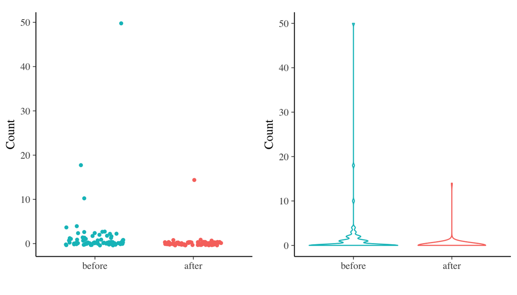

```r
## base plot
pp <- ggplot(stars_tidy, aes(x=time, y=count, color=time))
## jittered dotplot
p1 <- pp + geom_jitter(shape=16, position=position_jitter(0.3))
## violin plot
p2 <- pp + geom_violin()
## combine plots
p1 + p2 &
  theme(legend.position="none") &
  scale_x_discrete(limits=c("before","after")) &
  labs(x = "", y = "Count")
```

# Analyses

## Poisson models

### Frequentist using `glm()`

```r
## total survey area in m^2
area <- 3.75

## estimated mean density before
po_fit_glm_bef <- glm(before ~ 1, data = stars_wide, family = poisson(link = "log"))
summary(po_fit_glm_bef)
```

```
##
## Call:
## glm(formula = before ~ 1, family = poisson(link = "log"), data = stars_wide)
##
## Deviance Residuals:
##     Min       1Q   Median       3Q      Max
## -1.7819  -1.7819  -1.7819  -0.5007  15.7531
##
## Coefficients:
##             Estimate Std. Error z value Pr(>|z|)
## (Intercept)  0.46216    0.08874   5.208 1.91e-07 ***
## ---
## Signif. codes:  0 '***' 0.001 '**' 0.01 '*' 0.05 '.' 0.1 ' ' 1
##
## (Dispersion parameter for poisson family taken to be 1)
##
##     Null deviance: 488.06  on 79  degrees of freedom
## Residual deviance: 488.06  on 79  degrees of freedom
## AIC: 573.12
##
## Number of Fisher Scoring iterations: 7
```

```r
## convert from log to normal space
round(lambda_bef <- exp(coef(po_fit_glm_bef))/area, 2)
```

```
## (Intercept)
##        0.42
```

```r
## estimated mean density after
po_fit_glm_aft <- glm(after ~ 1, data = stars_wide, family = poisson(link = "log"))
summary(po_fit_glm_aft)
```

```
##
## Call:
## glm(formula = after ~ 1, family = poisson(link = "log"), data = stars_wide)
##
## Deviance Residuals:
##     Min       1Q   Median       3Q      Max
## -0.6519  -0.6519  -0.6519  -0.6519   9.4702
##
## Coefficients:
##             Estimate Std. Error z value Pr(>|z|)
## (Intercept)  -1.5488     0.2425  -6.386  1.7e-10 ***
## ---
## Signif. codes:  0 '***' 0.001 '**' 0.01 '*' 0.05 '.' 0.1 ' ' 1
##
## (Dispersion parameter for poisson family taken to be 1)
##
##     Null deviance: 126.55  on 79  degrees of freedom
## Residual deviance: 126.55  on 79  degrees of freedom
## AIC: 139.04
##
## Number of Fisher Scoring iterations: 7
```

```r
## convert from log to normal space
round(lambda_aft <- exp(coef(po_fit_glm_aft))/area, 3)
```

```
## (Intercept)
##       0.057
```

### Bayesian using `jags`

```r
## define Poisson model in JAGS
cat("

data {
  N <- dim(stars_wide);
}

model {
  ## PRIORS
  ln_lambda_bef ~ dnorm(0,0.01);
  ln_lambda_aft ~ dnorm(0,0.01);
  ## DERIVED PARAMS
  lambda_bef <- exp(ln_lambda_bef);
  lambda_aft <- exp(ln_lambda_aft);
  ## LIKELIHOOD
  for(i in 1:N[1]) {
    stars_wide[i,1] ~ dpois(lambda_aft * area);
    stars_wide[i,2] ~ dpois(lambda_bef * area);
  }
}

", file="poisson_glm.txt") ## end model description

## data to pass to JAGS
dat_jags <- c("stars_wide", "area")
## model params for JAGS to return
par_jags <- c("lambda_bef","lambda_aft")
## MCMC control params
mcmc_chains <- 4
mcmc_length <- 2e4
mcmc_burn <- 1e4
mcmc_thin <- 20
## total number of MCMC samples
mcmc_samp <- (mcmc_length-mcmc_burn)*mcmc_chains/mcmc_thin
## list of model info for JAGS
mod_jags <- list(data = dat_jags,
                 model.file = "poisson_glm.txt",
                 parameters.to.save = par_jags,
                 n.chains = as.integer(mcmc_chains),
                 n.iter = as.integer(mcmc_length),
                 n.burnin = as.integer(mcmc_burn),
                 n.thin = as.integer(mcmc_thin))
## fit model
po_fit_jags <- do.call(jags.parallel, mod_jags)
```

#### Examine parameter estimates

The first thing we can do is examine a summary table of the posterior samples.

```r
print(po_fit_jags)
```

```
## Inference for Bugs model at "poisson_glm.txt", fit using jags,
##  4 chains, each with 20000 iterations (first 10000 discarded), n.thin = 20
##  n.sims = 2000 iterations saved
##            mu.vect sd.vect    2.5%     25%     50%     75%   97.5%  Rhat
## lambda_aft   0.057   0.014   0.033   0.047   0.056   0.065   0.086 1.000
## lambda_bef   0.423   0.038   0.354   0.397   0.423   0.448   0.501 1.000
## deviance   710.166   2.017 708.212 708.755 709.554 710.930 715.228 1.006
##            n.eff
## lambda_aft  2000
## lambda_bef  2000
## deviance    1800
##
## For each parameter, n.eff is a crude measure of effective sample size,
## and Rhat is the potential scale reduction factor (at convergence, Rhat=1).
##
## DIC info (using the rule, pD = var(deviance)/2)
## pD = 2.0 and DIC = 712.2
## DIC is an estimate of expected predictive error (lower deviance is better).
```

Visual summaries of the results can also be useful. Here are histograms of the posterior samples (left) and a summary of the median and 95% credible interval of the posterior samples (right).

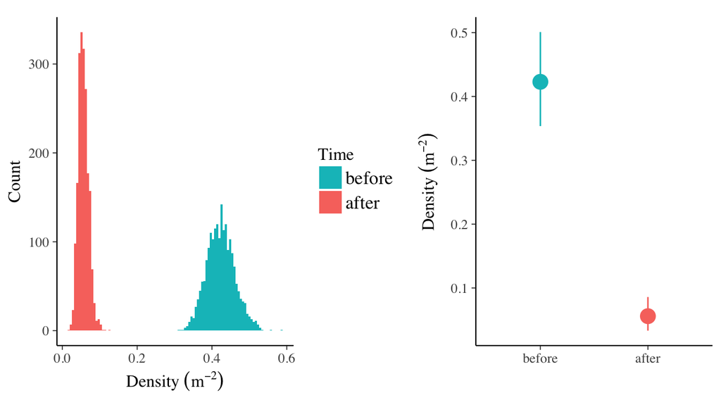

```r
## gather posteriors samples
pdat <- data.frame(Time = rep(c("before","after"), ea=mcmc_samp),
                   samples = c(po_fit_jags$BUGSoutput$sims.list$lambda_bef,
                               po_fit_jags$BUGSoutput$sims.list$lambda_aft))
## summary of posteriors
pdat2 <- pdat %>%
  group_by(Time) %>%
  summarize(lo = quantile(samples, 0.025),
            med = quantile(samples, 0.5),
            hi = quantile(samples, 0.975))
## histogram of posteriors
p1 <- ggplot(pdat, aes(samples, fill = Time)) +
  geom_histogram(bins = 100) +
  guides(fill = guide_legend(reverse=TRUE)) +
  labs(x = expression(Density~(m^-2)), y = "Count")
p2 <- ggplot(pdat2, aes(x=Time, y=med, color=Time)) +
  geom_point(aes(size=1.5)) +
  geom_errorbar(aes(ymin=lo, ymax=hi), width=0) +
  scale_x_discrete(limits=c("before","after")) +
  xlab("") +
  ylab(expression(Density~(m^-2))) +
  theme(legend.position="none")
p1 + p2
```

### Bayesian using `stan_glm`

```r
## before
po_fit_stan_bef <- stan_glm(before ~ 1, data = stars_wide, family = poisson(link = "log"),
                            prior = normal(0, 1), prior_intercept = normal(0, 10),
                            chains = 4, iter = 2000, warmup = 1500)
## after
po_fit_stan_aft <- stan_glm(after ~ 1, data = stars_wide, family = poisson(link = "log"),
                            prior = normal(0, 1), prior_intercept = normal(0, 10),
                            chains = 4, iter = 2000, warmup = 1500)
```

```r
## before
## convert from log to normal space
summary(po_fit_stan_bef)
```

```
##
## Model Info:
##
##  function:     stan_glm
##  family:       poisson [log]
##  formula:      before ~ 1
##  algorithm:    sampling
##  priors:       see help('prior_summary')
##  sample:       2000 (posterior sample size)
##  observations: 80
##  predictors:   1
##
## Estimates:
##                 mean   sd     2.5%   25%    50%    75%    97.5%
## (Intercept)      0.5    0.1    0.3    0.4    0.5    0.5    0.6
## mean_PPD         1.6    0.2    1.2    1.5    1.6    1.7    2.0
## log-posterior -289.3    0.7 -291.3 -289.4 -289.0 -288.8 -288.8
##
## Diagnostics:
##               mcse Rhat n_eff
## (Intercept)   0.0  1.0   636
## mean_PPD      0.0  1.0  1038
## log-posterior 0.0  1.0   578
##
## For each parameter, mcse is Monte Carlo standard error, n_eff is a crude measure of effective sample size, and Rhat is the potential scale reduction factor on split chains (at convergence Rhat=1).
```

```r
round(exp(coef(po_fit_stan_bef))/area, 2)
```

```
## (Intercept)
##        0.42
```

```r
## after
## convert from log to normal space
round(exp(coef(po_fit_stan_aft))/area, 3)
```

```
## (Intercept)
##       0.055
```

```r
summary(po_fit_stan_aft)
```

```
##
## Model Info:
##
##  function:     stan_glm
##  family:       poisson [log]
##  formula:      after ~ 1
##  algorithm:    sampling
##  priors:       see help('prior_summary')
##  sample:       2000 (posterior sample size)
##  observations: 80
##  predictors:   1
##
## Estimates:
##                 mean   sd    2.5%   25%   50%   75%   97.5%
## (Intercept)    -1.6    0.3  -2.1   -1.7  -1.6  -1.4  -1.1
## mean_PPD        0.2    0.1   0.1    0.2   0.2   0.3   0.4
## log-posterior -72.3    0.8 -74.6  -72.5 -72.0 -71.8 -71.8
##
## Diagnostics:
##               mcse Rhat n_eff
## (Intercept)   0.0  1.0  459
## mean_PPD      0.0  1.0  894
## log-posterior 0.0  1.0  368
##
## For each parameter, mcse is Monte Carlo standard error, n_eff is a crude measure of effective sample size, and Rhat is the potential scale reduction factor on split chains (at convergence Rhat=1).
```

Here are histograms of the posterior samples (left) and a summary of the median and 95% credible interval of the posterior samples (right).

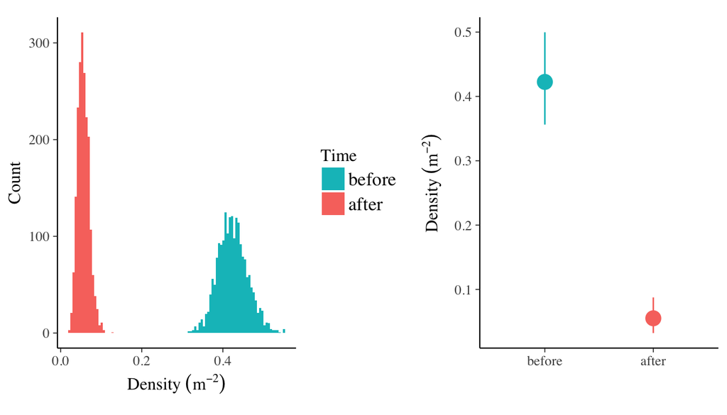

```r
## gather posteriors samples
pdat <- data.frame(Time = rep(c("before","after"), ea=mcmc_samp),
                   samples = exp(c(as.matrix(po_fit_stan_bef),
                                   as.matrix(po_fit_stan_aft)))/area)
## summary of posteriors
pdat2 <- pdat %>%
  group_by(Time) %>%
  summarize(lo = quantile(samples, 0.025),
            med = quantile(samples, 0.5),
            hi = quantile(samples, 0.975))
## histogram of posteriors
p1 <- ggplot(pdat, aes(samples, fill = Time)) +
  geom_histogram(bins = 100) +
  guides(fill = guide_legend(reverse=TRUE)) +
  labs(x = expression(Density~(m^-2)), y = "Count")
p2 <- ggplot(pdat2, aes(x=Time, y=med, color=Time)) +
  geom_point(aes(size=1.5)) +
  geom_errorbar(aes(ymin=lo, ymax=hi), width=0) +
  scale_x_discrete(limits=c("before","after")) +
  xlab("") +
  ylab(expression(Density~(m^-2))) +
  theme(legend.position="none")
p1 + p2
```

## Negative binomial models

### Bayesian using `jags`

```r
## define negative binomial model in JAGS
cat("

data {
  N <- dim(stars_wide);
}

model {
  ## PRIORS
  r_bef ~ dnorm(0,0.01) T(0,);
  r_aft ~ dnorm(0,0.01) T(0,);
  lambda_bef ~ dnorm(0,0.1) T(0,);
  lambda_aft ~ dnorm(0,0.1) T(0,);
  ## DERIVED PARAMS
  mu_bef <- lambda_bef * area;
  mu_aft <- lambda_aft * area;
  p_aft <- r_aft / (r_aft + mu_aft);
  p_bef <- r_bef / (r_bef + mu_bef);
  mean_bef <- r_bef * (1 - p_bef) / p_bef;
  mean_aft <- r_aft * (1 - p_aft) / p_aft;
  var_bef <- mean_bef / p_bef;
  var_aft <- mean_aft / p_aft;
  ## LIKELIHOOD
  for(i in 1:N[1]) {
    stars_wide[i,1] ~ dnegbin(p_aft, r_aft);
    stars_wide[i,2] ~ dnegbin(p_bef, r_bef);
  }
}

", file="negbin_glm.txt") ## end model description

## update model params for JAGS to return
par_jags <- c("lambda_bef","mean_bef","var_bef","lambda_aft","mean_aft","var_aft")

## update list of model info for JAGS
mod_jags$model.file <-"negbin_glm.txt"
mod_jags$parameters.to.save <- par_jags

## fit model
nb_fit_jags <- do.call(jags.parallel, mod_jags)
```

#### Examine parameter estimates

Again we can examine a summary table of the parameter estimates. Notice that in this case, we also have estimates for mean and variance of the density of stars per 3.75 m<sup>2</sup>.

```r
print(nb_fit_jags)
```

```
## Inference for Bugs model at "negbin_glm.txt", fit using jags,
##  4 chains, each with 20000 iterations (first 10000 discarded), n.thin = 20
##  n.sims = 2000 iterations saved
##             mu.vect   sd.vect    2.5%     25%     50%     75%     97.5%
## lambda_aft    0.723     1.126   0.030   0.096   0.250   0.800     4.198
## lambda_bef    0.484     0.138   0.285   0.384   0.460   0.556     0.818
## mean_aft      2.711     4.221   0.113   0.360   0.938   3.001    15.744
## mean_bef      1.815     0.518   1.067   1.439   1.727   2.086     3.067
## var_aft    2964.377 10679.746   0.549   5.559  45.708 733.358 29382.594
## var_bef      18.377    13.227   5.835  10.245  14.553  22.134    53.578
## deviance    287.547     3.393 282.628 285.075 287.167 289.418   295.362
##             Rhat n.eff
## lambda_aft 1.001  2000
## lambda_bef 1.001  2000
## mean_aft   1.001  2000
## mean_bef   1.001  2000
## var_aft    1.001  2000
## var_bef    1.001  1700
## deviance   1.001  2000
##
## For each parameter, n.eff is a crude measure of effective sample size,
## and Rhat is the potential scale reduction factor (at convergence, Rhat=1).
##
## DIC info (using the rule, pD = var(deviance)/2)
## pD = 5.8 and DIC = 293.3
## DIC is an estimate of expected predictive error (lower deviance is better).
```

This time I use a frequency plot instead of a histogram because the overlap in the distributions makes them hard to discern otherwise.

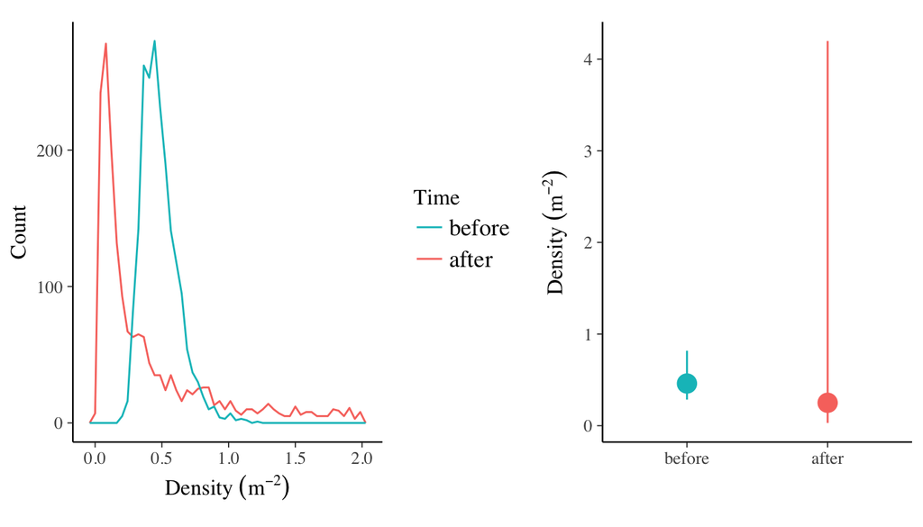

```r
## gather posteriors samples
pdat <- data.frame(Time = rep(c("before","after"), ea=mcmc_samp),
                   samples = c(nb_fit_jags$BUGSoutput$sims.list$lambda_bef,
                               nb_fit_jags$BUGSoutput$sims.list$lambda_aft))
## summary of posteriors
pdat2 <- pdat %>%
  group_by(Time) %>%
  summarize(lo = quantile(samples, 0.025),
            med = quantile(samples, 0.5),
            hi = quantile(samples, 0.975))
## trim away big values for histogram
pdat <- pdat %>%
  filter(samples <= 2)
## histogram of posteriors
p1 <- ggplot(pdat, aes(samples, color = Time)) +
  geom_freqpoly(bins = 50) +
  guides(color = guide_legend(reverse=TRUE)) +
  labs(x = expression(Density~(m^-2)), y = "Count")
p2 <- ggplot(pdat2, aes(x=Time, y=med, color=Time)) +
  geom_point(aes(size=1.5)) +
  geom_errorbar(aes(ymin=lo, ymax=hi), width=0) +
  scale_x_discrete(limits=c("before","after")) +
  labs(x = "", y = expression(Density~(m^-2))) +
  theme(legend.position="none")
p1 + p2
```

### Bayesian using `stan_glm`

```r
## before
nb_fit_stan_bef <- stan_glm.nb(before ~ 1, data = stars_wide,
                            prior_intercept = normal(0, 10), prior_aux = normal(0, 10),
                            chains = 4, iter = 6000, warmup = 1000, thin = 10)
## after
nb_fit_stan_aft <- stan_glm.nb(after ~ 1, data = stars_wide,
                            prior_intercept = normal(0, 10), prior_aux = normal(0, 10),
                            chains = 4, iter = 6000, warmup = 1000, thin = 10)
```

#### Examine parameter estimates

And here are the results based on `summary()`. Note that the estimates of the mean and overdispersion are in log-space.

```r
## before
summary(nb_fit_stan_bef)
```

```
##
## Model Info:
##
##  function:     stan_glm.nb
##  family:       neg_binomial_2 [log]
##  formula:      before ~ 1
##  algorithm:    sampling
##  priors:       see help('prior_summary')
##  sample:       2000 (posterior sample size)
##  observations: 80
##  predictors:   1
##
## Estimates:
##                         mean   sd     2.5%   25%    50%    75%    97.5%
## (Intercept)              0.5    0.3    0.0    0.3    0.5    0.6    1.0
## reciprocal_dispersion    0.2    0.1    0.1    0.2    0.2    0.3    0.4
## mean_PPD                 1.7    0.6    0.8    1.2    1.6    2.0    3.1
## log-posterior         -125.5    1.0 -128.2 -125.8 -125.2 -124.7 -124.5
##
## Diagnostics:
##                       mcse Rhat n_eff
## (Intercept)           0.0  1.0  1896
## reciprocal_dispersion 0.0  1.0  1602
## mean_PPD              0.0  1.0  2000
## log-posterior         0.0  1.0  2000
##
## For each parameter, mcse is Monte Carlo standard error, n_eff is a crude measure of effective sample size, and Rhat is the potential scale reduction factor on split chains (at convergence Rhat=1).
```

```r
## after
summary(nb_fit_stan_aft)
```

```
##
## Model Info:
##
##  function:     stan_glm.nb
##  family:       neg_binomial_2 [log]
##  formula:      after ~ 1
##  algorithm:    sampling
##  priors:       see help('prior_summary')
##  sample:       2000 (posterior sample size)
##  observations: 80
##  predictors:   1
##
## Estimates:
##                         mean   sd    2.5%   25%   50%   75%   97.5%
## (Intercept)            -1.2    1.1  -2.7   -1.9  -1.4  -0.8   1.4
## reciprocal_dispersion   0.0    0.0   0.0    0.0   0.0   0.0   0.1
## mean_PPD               14.9  539.1   0.0    0.1   0.2   0.4   4.8
## log-posterior         -34.2    1.1 -37.4  -34.7 -33.9 -33.4 -33.1
##
## Diagnostics:
##                       mcse Rhat n_eff
## (Intercept)            0.0  1.0 1871
## reciprocal_dispersion  0.0  1.0 1841
## mean_PPD              12.1  1.0 2000
## log-posterior          0.0  1.0 1819
##
## For each parameter, mcse is Monte Carlo standard error, n_eff is a crude measure of effective sample size, and Rhat is the potential scale reduction factor on split chains (at convergence Rhat=1).
```

Here are histograms of the posterior samples (left) and a summary of the median and 95% credible interval of the posterior samples (right).

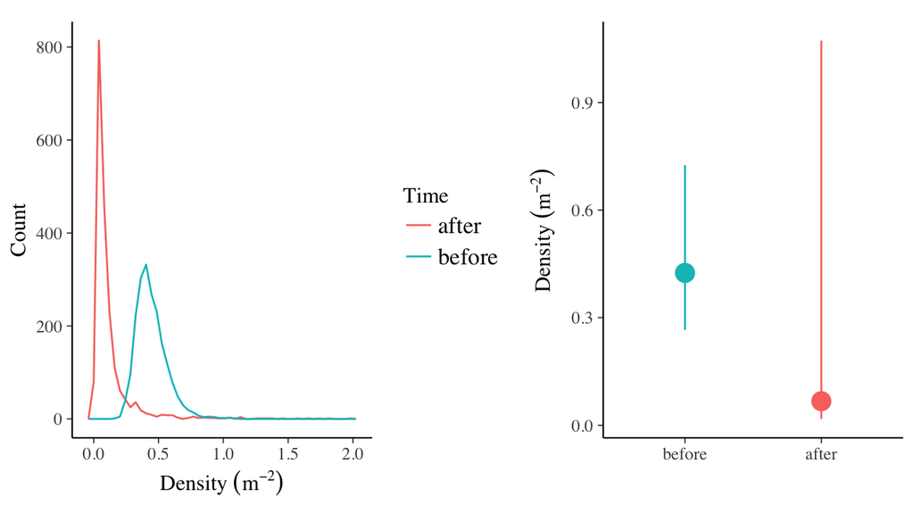

```r
## gather posteriors samples
pdat <- data.frame(Time = rep(c("before","after"), ea=mcmc_samp),
                   samples = exp(c(as.matrix(nb_fit_stan_bef)[,1],
                                   as.matrix(nb_fit_stan_aft)[,1]))/area)
## summary of posteriors
pdat2 <- pdat %>%
  group_by(Time) %>%
  summarize(lo = quantile(samples, 0.025),
            med = quantile(samples, 0.5),
            hi = quantile(samples, 0.975))
## trim away big values for histogram
pdat <- pdat %>%
  filter(samples <= 2)
## histogram of posteriors
p1 <- ggplot(pdat, aes(samples, color = Time)) +
  geom_freqpoly(bins = 50) +
  guides(fill = guide_legend(reverse=TRUE)) +
  labs(x = expression(Density~(m^-2)), y = "Count")
p2 <- ggplot(pdat2, aes(x=Time, y=med, color=Time)) +
  geom_point(aes(size=1.5)) +
  geom_errorbar(aes(ymin=lo, ymax=hi), width=0) +
  scale_x_discrete(limits=c("before","after")) +
  xlab("") +
  ylab(expression(Density~(m^-2))) +
  theme(legend.position="none")
p1 + p2
```